# chooseGCM Tutorial

Luíz Fernando Esser

2023-06-13

## Downloading WorldClim 2.1 data

```r
gcm_names <- sort(c('ac','ip','me','mi','mp','ml'))

# WorldClim_data(period = 'future', variable = 'bioc', year = '2090', gcm = gcm_names, ssp = '585', resolution = 10)
```

## Importing and transforming data

Now let’s import GCMs to R in a list of stacks and name the list with the names of the GCMs.

```r
s <- list.files('input_data/WorldClim_data_future', pattern = '.tif', full.names = T) |>
  lapply(function(x){s <- raster::stack(x)
                     names(s) <- paste0('bio_',1:19) # Rename rasters
                     return(s)})
names(s) <- gcm_names
```

In each function, data will be transformed. To do that you will always need to provide at least: (1) the list of stacks, (2) the variables you want to use in analysis and (3) the shapefile of your study area.

```r
var_names <- c('bio_1', 'bio_12')
study_area <- raster::extent(c(-57, -22, -48, -33)) # you can use a shapefile here
```

## Exploratory analysis

In chooseGCM we implemented functions to analyze GCMs attributes.

```r
# Summary of GCMs
s_sum <- summary_gcms(s, var_names, study_area)
s_sum
```

```
## $ac
##          min quantile_0.25 median       mean quantile_0.75    max         sd
## bio_1   18.5          20.6   21.1   20.93511          21.3   22.4  0.6729885
## bio_12 913.6        1247.9 1301.3 1279.45467        1337.1 1428.6 96.8010876
##          NAs n_cells
## bio_1  18675   18900
## bio_12 18675   18900
##
## $ip
##           min quantile_0.25 median       mean quantile_0.75    max          sd
## bio_1    18.6          20.8   21.1   21.02133          21.4   22.3   0.6173736
## bio_12 1050.9        1449.7 1497.3 1472.14978        1525.6 1623.0 101.0357594
##          NAs n_cells
## bio_1  18675   18900
## bio_12 18675   18900
##
## $me
##          min quantile_0.25 median     mean quantile_0.75    max         sd
## bio_1   17.2          18.8   19.2   19.120          19.5   20.5  0.6005206
## bio_12 924.9        1323.6 1369.0 1341.552        1395.1 1476.6 98.6417447
##          NAs n_cells
## bio_1  18675   18900
## bio_12 18675   18900
##
## $mi
##          min quantile_0.25 median       mean quantile_0.75    max         sd
## bio_1   17.0          18.6   19.0   18.96844          19.3   20.3  0.5977859
## bio_12 924.2        1303.0 1352.7 1326.58311        1382.9 1456.7 96.3602897
##          NAs n_cells
## bio_1  18675   18900
## bio_12 18675   18900
##
## $ml
##          min quantile_0.25 median       mean quantile_0.75    max          sd
## bio_1   17.4          19.1   19.6   19.50622          20.0   21.0   0.6787307
## bio_12 914.5        1314.5 1364.8 1343.51645        1408.7 1494.3 107.0979526
##          NAs n_cells
## bio_1  18675   18900
## bio_12 18675   18900
##
## $mp
##          min quantile_0.25 median       mean quantile_0.75    max          sd
## bio_1   17.4          19.1   19.6   19.50622          20.0   21.0   0.6787307
## bio_12 914.5        1314.5 1364.8 1343.51645        1408.7 1494.3 107.0979526
##          NAs n_cells
## bio_1  18675   18900
## bio_12 18675   18900
```

```r
# Pearson Correlation between GCMs
s_cor <- cor_gcms(s, var_names, study_area, method = "pearson")
s_cor
```

```
## $cor_matrix
##           ac        ip        me        mi        ml        mp
## ac 1.0000000 0.9772652 0.9772104 0.9683704 0.9672557 0.9672557
## ip 0.9772652 1.0000000 0.9911019 0.9886388 0.9772004 0.9772004
## me 0.9772104 0.9911019 1.0000000 0.9958763 0.9726183 0.9726183
## mi 0.9683704 0.9886388 0.9958763 1.0000000 0.9605683 0.9605683
## ml 0.9672557 0.9772004 0.9726183 0.9605683 1.0000000 1.0000000
## mp 0.9672557 0.9772004 0.9726183 0.9605683 1.0000000 1.0000000
##
## $cor_plot
```

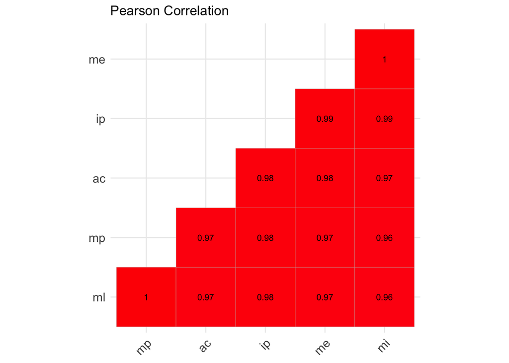

```r
# Euvlidean Distance between GCMs
s_dist <- dist_gcms(s, var_names, study_area, method = "euclidean")
s_dist
```

```
## $distances
##          ac       ip       me       mi       ml
## ip 41.36560
## me 41.41541 25.87875
## mi 48.79107 29.24194 17.61715
## ml 49.64341 41.42447 45.39663 54.47737
## mp 49.64341 41.42447 45.39663 54.47737  0.00000
##
## $heatmap
```

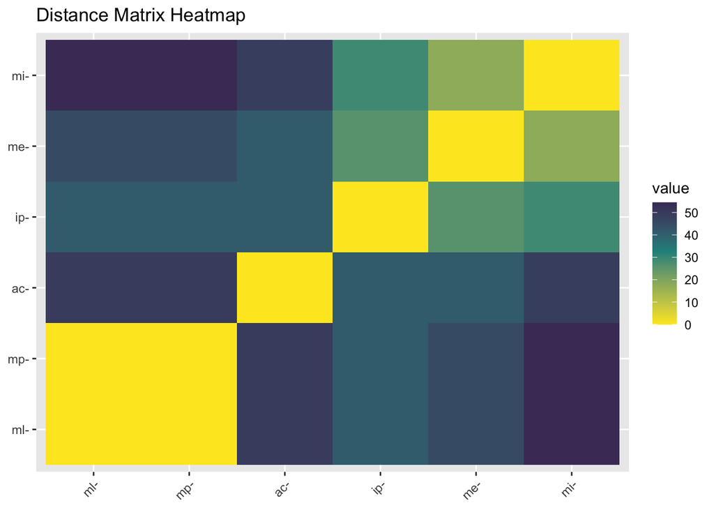

## Obtain clusters

Clusters in chooseGCM are obtained through k-means, a unsupervised machine learning algorithm. k is the number of clusters, which in this case is the number of GCMs the modeller wants to use in projections.To build a distance matrix considering multiple variables to each GCM we use a flattening strategy, where values are concatenated in one unique vector to each GCM. In the process, we need to scale variables so they end up with the same measure. This matrix will be used to calculate the clusters.

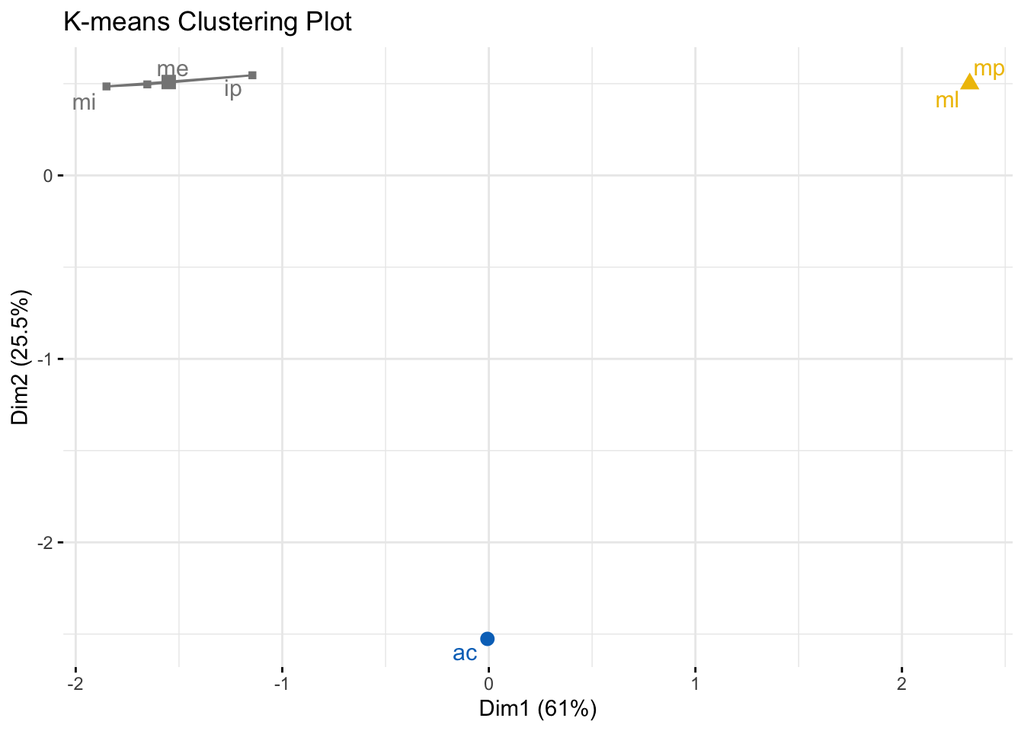

```r
kmeans_gcms(s, var_names, study_area, k = 3,  method = "euclidean")
```

Alternatively, one could run the analysis with raw environmental data by not setting any value to method.

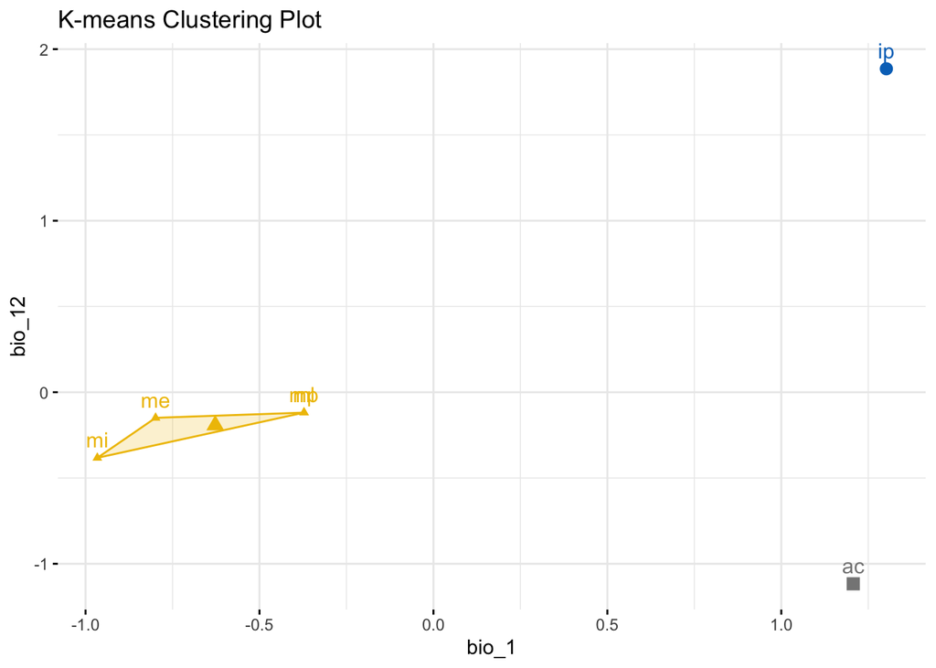

```r
kmeans_gcms(s, var_names, study_area, k = 3)
```

We can also obtain clusters through hierarchical clustering.

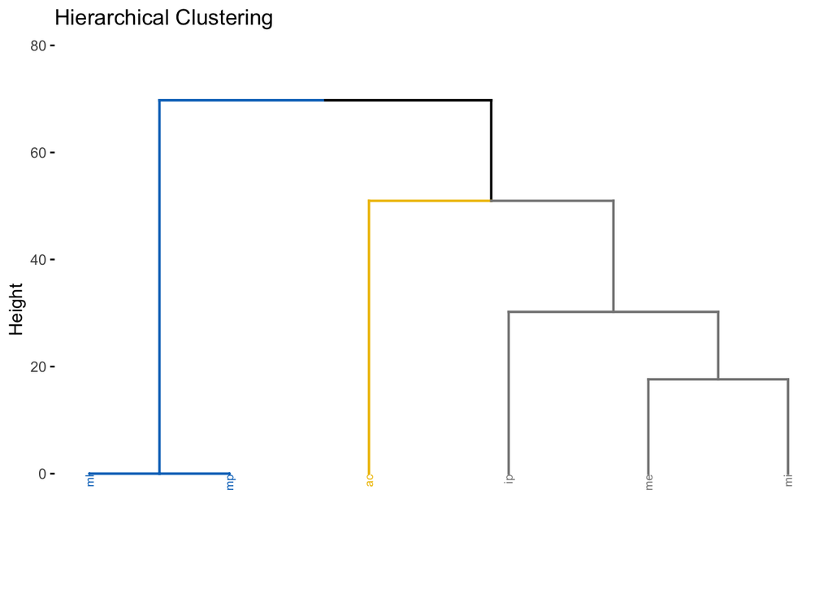

```r
hclust_gcms(s, var_names, study_area, k = 3, n = 1000)
```

But how many clusters are good? There is metrics to understand that.

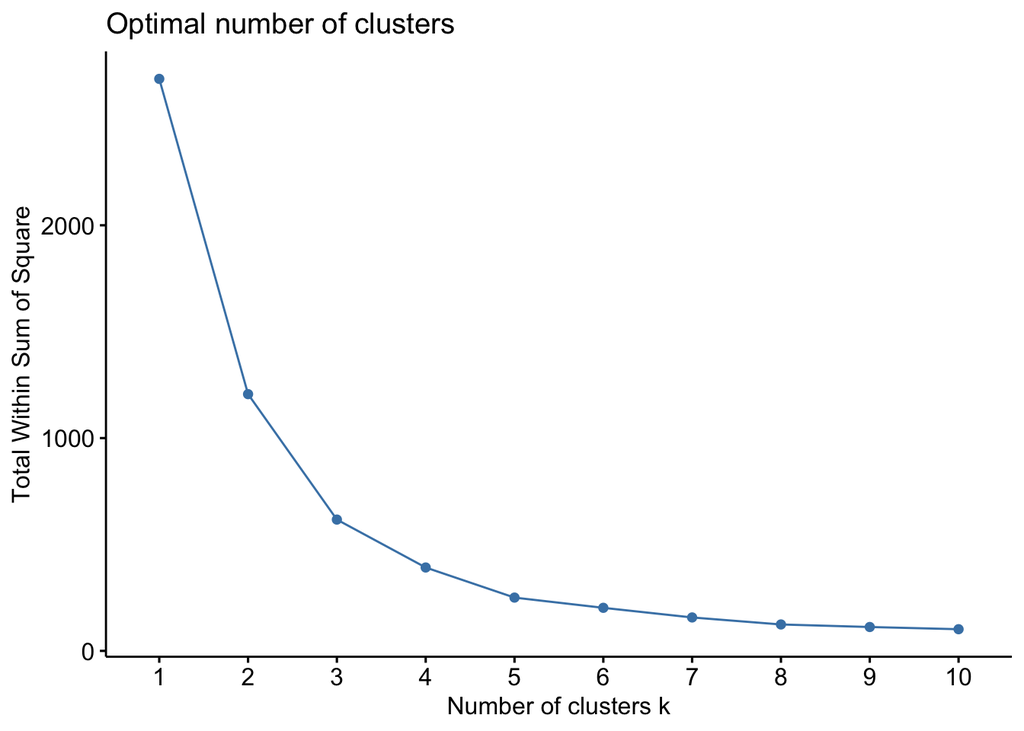

```r
optimize_clusters(s, var_names, study_area, method = 'wss', n = 1000)
```

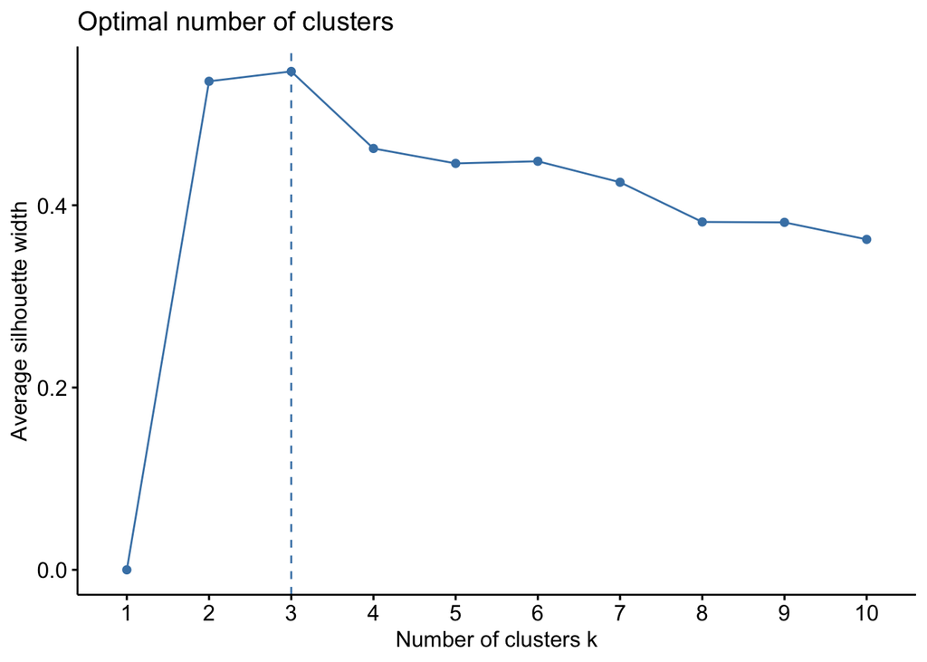

```r
optimize_clusters(s, var_names, study_area, method = 'silhouette', n = 1000)
```

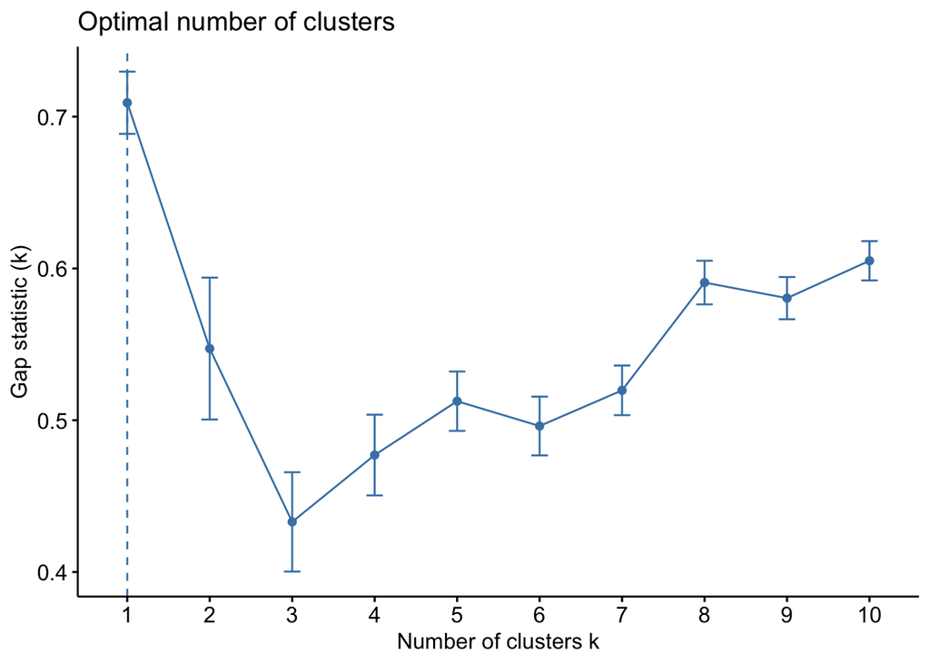

```r
optimize_clusters(s, var_names, study_area, method = 'gap_stat', n = 1000)
```

## Putting everything together

There is the option to run each function in a separate to better understand what is happening and to better parameterize each step. However there is a wrapper to help run everything at once.

```r
compare_gcms(s, var_names, study_area, k = 3)
```

```
## $suggested_gcms
##    1    2    3
## "me" "ml" "ac"
##
## $statistics_gcms
```

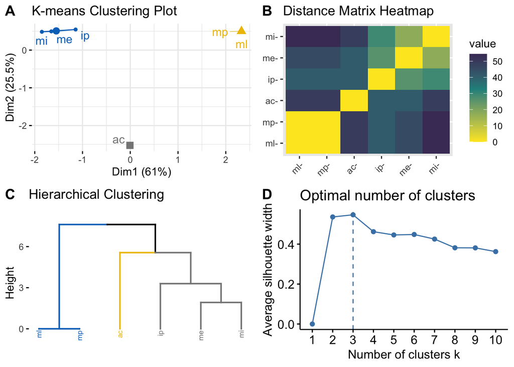